# Prospecção Séries Temporais

G4: Edinaldo de Alencar / Igor Freire / Ramon Araújo / Ricardo Ribeiro

16 de outubro de 2014

# Importação da base de dados

Pacote utilizado para leitura em formato de séries temporais:

```r
library(zoo)
```

Importar as bases de dados utilizando `read.zoo`:

```r
# Mudar para o diretório onde está a base de dados
setwd(paste("/Users/igorfreire/Documents/Mestrado/UFPA/",
               "/Mineração de Dados/data-mining-ppgee/",
               "/trabalho-2-forecast/", sep=""));

# Inicialmente ler a base de dados diários como um data frame (através de read.csv)
dataframe_diario <- read.csv(file = "dataset_diario.csv", sep = ";", dec = ",", header = TRUE)
# Em seguida, converter para uma série temporal (lista indexada pela data)
dataset_diario <- zoo(as.matrix(dataframe_diario[, -1:-2]), as.Date(dataframe_diario[,1], format = "%d/%m/%y"))
# Obs: em "format" usa-se y minusculo, pois a data está no formato dd/mm/yy

# A função read.zoo() abaixo não retorna lista com vetores categóricos e numéricos ao mesmo tempo.
# Isto é, se houver dados categóricos e numéricos na base, os numéricos serão convertidos.
# Por isso, a base com dados diários não foi lida diretamente com read.zoo. A base com dados mensais
# pode ser lida diretamente com read.zoo()
# Ler o .csv como uma série temporal (indexado pela data)
dataset_mensal <- read.zoo(file = "dataset_mensal.csv", sep = ";", dec = ",", header = TRUE,
        index = 1, tz = "", FUN = as.yearmon, format = "%m/%Y", drop = FALSE)
# index ->  coluna do arquivo .csv que contém a data
# Obs: em "format" usa-se Y maiúsculo, pois a data está no formato mm/yyyy
```

- `dataset_diario` é a base com valores de fluxos diários de 2002 à 2009.
- `dataset_mensal` é a base com os valores de fluxo mensais de 1992 à 2009.

### Notar que é necessário definir:

1. O caractere que separa as entradas no arquivo *.csv* (`sep =`)
2. O caractere separador de casas decimais do atributo numérico presente nas bases de dados (`dec =`)

# Informação sobre os dias da semana

**Observar** que a informação sobre os dias da semana é redundante, pois pode ser obtida através de:

```r
dia <- weekdays(index(dataset_diario))
```

que tem como resultado, por exemplo, para as 10 primeiras amostras da base:

```r
head(dia, 10)
```

```
##  [1] "Terça Feira"   "Quarta Feira"  "Quinta Feira"  "Sexta Feira"
##  [5] "Sábado"        "Domingo"       "Segunda Feira" "Terça Feira"
##  [9] "Quarta Feira"  "Quinta Feira"
```

o qual pode ser confirmado comparando com as 10 primeiras entradas na coluna “dia” da base:

```r
head(dataframe_diario[,2], 10)
```

```
##  [1] ter qua qui sex sab dom seg ter qua qui
## Levels: dom qua qui sab seg sex ter
```

Por isso, na leitura da base em `dataset_diario` esta coluna foi ignorada.

# Inspeção do conjunto de dados

- Dataset diário:

```r
summary(dataset_diario)
```

```
##      Index            dataset_diario
##  Min.   :2002-01-01   Min.   :11130
##  1st Qu.:2004-01-01   1st Qu.:19468
##  Median :2005-12-31   Median :22811
##  Mean   :2005-12-31   Mean   :23158
##  3rd Qu.:2007-12-31   3rd Qu.:26712
##  Max.   :2009-12-31   Max.   :34292
```

```r
summary(dataset_mensal)
```

```
##      Index          fluxo
##  Min.   :1992   Min.   :261544
##  1st Qu.:1996   1st Qu.:408961
##  Median :2001   Median :529912
##  Mean   :2001   Mean   :548440
##  3rd Qu.:2005   3rd Qu.:662250
##  Max.   :2010   Max.   :982708
```

# Séries temporais

Converter os dados para o formato de série temporal no R:

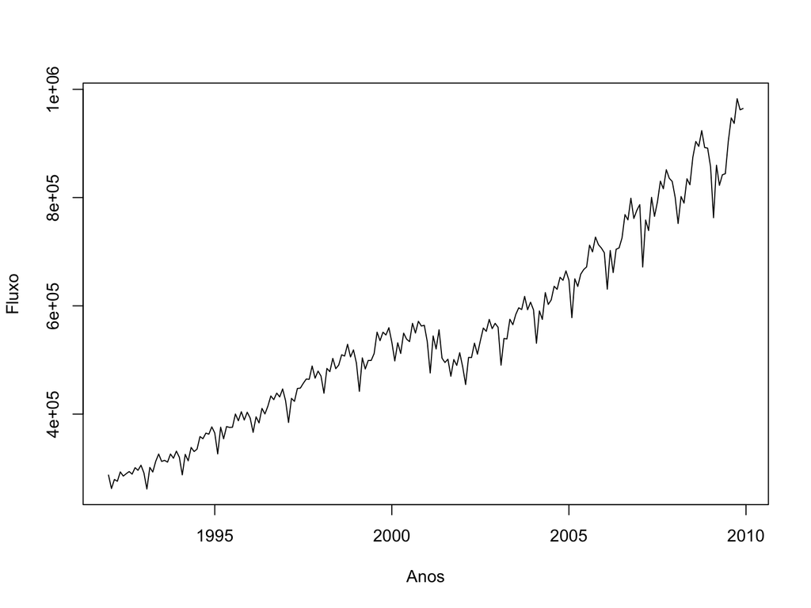

```r
# Frequency --> numero de observacoes por unidade de tempo
# define a unidade de tempo (e.g. 12, unidade de tempo = ano)
tsMensal <- ts(dataset_mensal, frequency=12, start=1992)
plot(tsMensal, xlab="Anos", ylab="Fluxo")
```

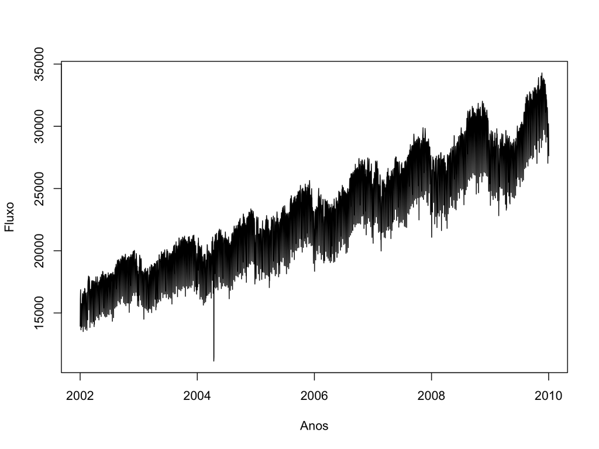

```r
# Periodo (unidade de tempo) = ano
tsDiario <- ts(dataset_diario, start=c(2002,1,1), frequency=365)
plot(tsDiario, xlab="Anos", ylab="Fluxo")
```

# Decomposição das séries temporais

Decompor a série temporal em:

- *Trend*: padrão de crescimento ao longo do tempo
- *Seasonal*: padrão recorrente em um determinado período de tempo
- *Irregular* (random): parte irregular (ruidosa), sem padrão sazonal ou tendência

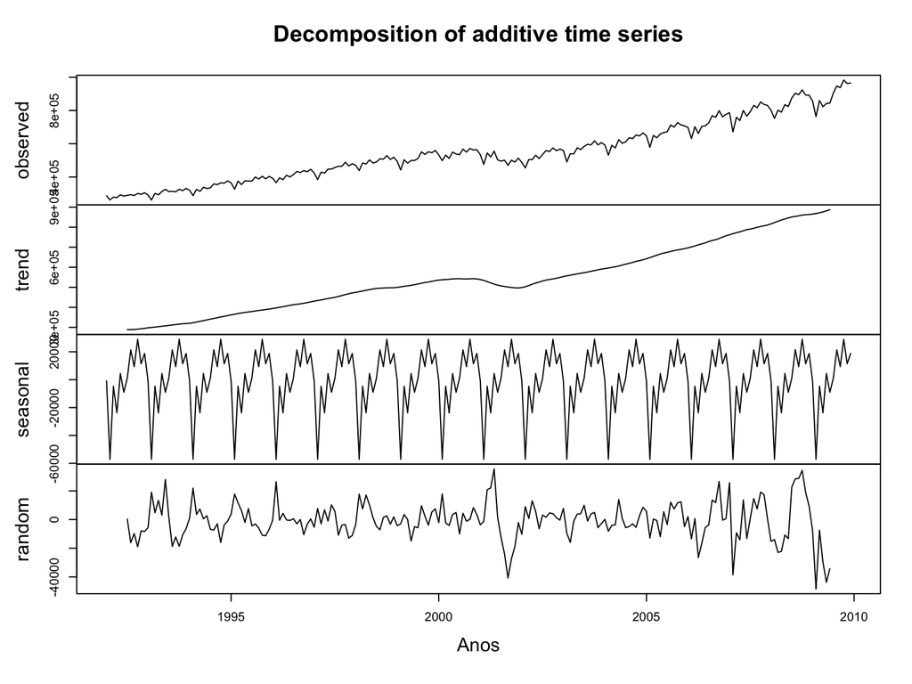

```r
plot(decompose(tsMensal), xlab="Anos")
```

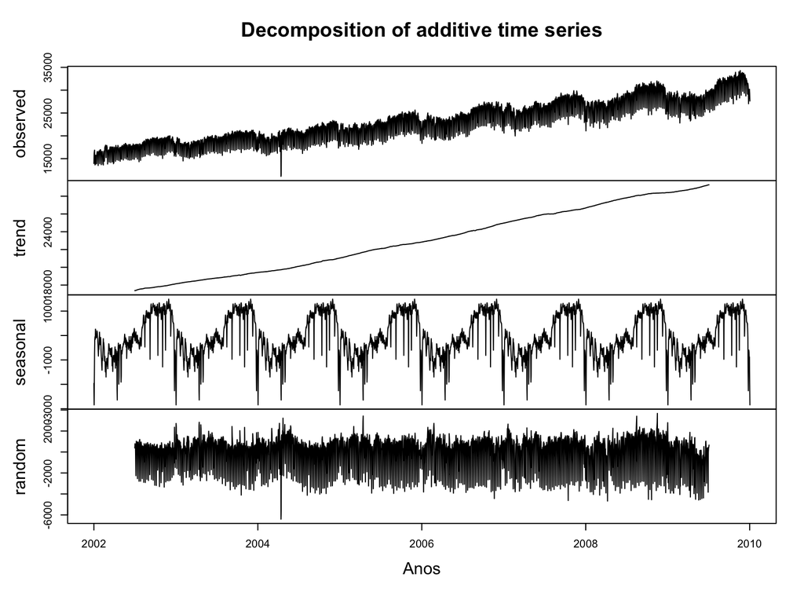

```r
plot(decompose(tsDiario), xlab="Anos")
```

# Separação dos dados

Separação da série temporal `tsMensal` em séries contendo dados de treinamento e de teste.

```r
tsMensalTrain <- window(tsMensal, end=(2006-0.01)) # De Jan 1992 até Dez 2005
tsMensalTest <- window(tsMensal, start=2006) # De Jan 2006 até Dez 2009
```

Visualização

```r
tsMensalTest
```

```
##         Jan    Feb    Mar    Apr    May    Jun    Jul    Aug    Sep    Oct
## 2006 698072 630797 702232 661458 704591 707014 725561 768589 758857 798840
## 2007 786975 671785 758547 739111 800366 765350 792298 830373 816278 851496
## 2008 800602 752107 801890 789809 834790 823701 874821 903554 894623 923699
## 2009 856877 762838 859820 822665 842152 844119 903711 947233 937079 982708
##         Nov    Dec
## 2006 761474 776307
## 2007 835756 829870
## 2008 892443 891430
## 2009 962154 964567
```

# Métodos simplísticos

- **Média**: valor futuro predito é a média dos dados históricos
- **Näive**: valor futuro predito é igual ao último dado observado
- **Sazonal**: valor futuro predito é igual dado no período anterior (dada uma divisão em períodos que representa a sazonalidade do conjunto) correspondente. Por exemplo, se a sazonalidade está em anos e os dados são mensais, o valor predito no mês de outubro do ano futuro é igual ao valor no mês de outubro observado no ano passado.
- *Drift*: valor futuro predito é igual ao último valor observado mais a média da diferença entre dados consecutivos (captura a tendência)

# Estratégia de Avaliação dos Métodos

Apresenta-se a seguir:

**Nota**:

- **in-sample**: medida dentro do conjunto no qual os modelos foram treinados.
- **out-of-sample**: medida no conjunto de testes.

Pacote utilizado (ver (R. J. Hyndman 2014) e (Leek 2014)):

```r
library(forecast)
```

Funções utilizadas:

- `meanf()`
- `naive()`
- `snaive()`
- `rwf()`

Saída: objeto `forecast`, contendo:

- Série Original
- Predições
- Método utilizado
- Intervalos de Predição
- Resíduos

# Acurácia

Medidores usuais:

- ME: Mean error
- MAE: Mean absolute error
- RMSE: Root mean square error
- MAPE: Mean absolute percentage error

Diferentemente do ME, MAE e RMSE, o medidor MAPE é independente da escala.

### MAPE:

$M = \frac{1}{n} \sum \limits_{t=1}^{n} \left| \frac{A_t - F_t}{A_t} \right|,$

onde $A_t$ é o valor verdadeiro, $F_t$ é o valor predito e $n$ é o número de amostras temporais preditas.

# Avaliação dos Métodos

#### Série temporal de treinamento

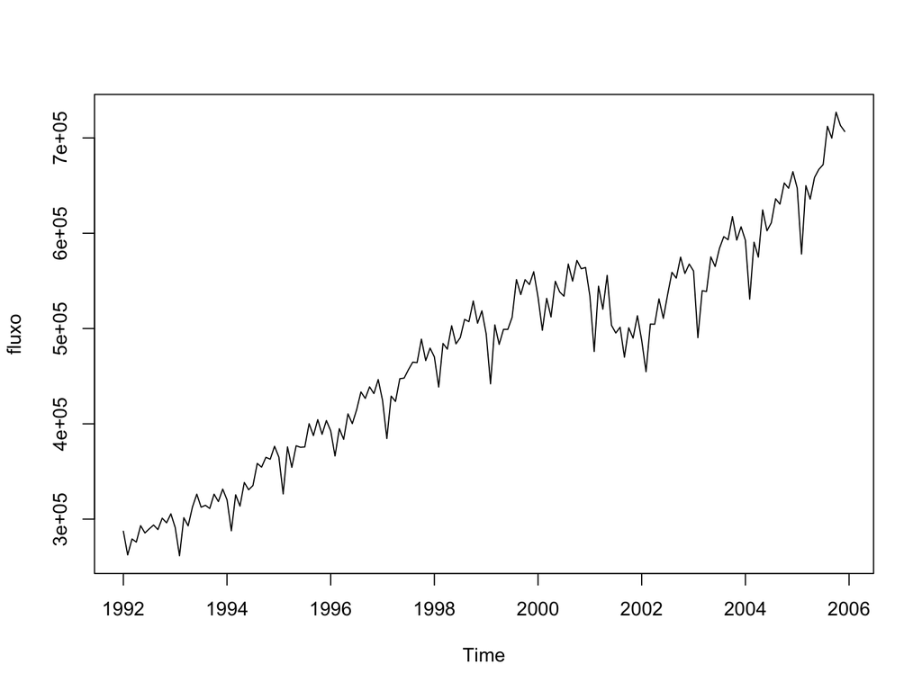

```r
# Dados de treinamento
plot(tsMensalTrain)
```

#### Número de meses para os quais deseja-se prever o fluxo

```r
mesesAPrever <- 12
```

#### Média

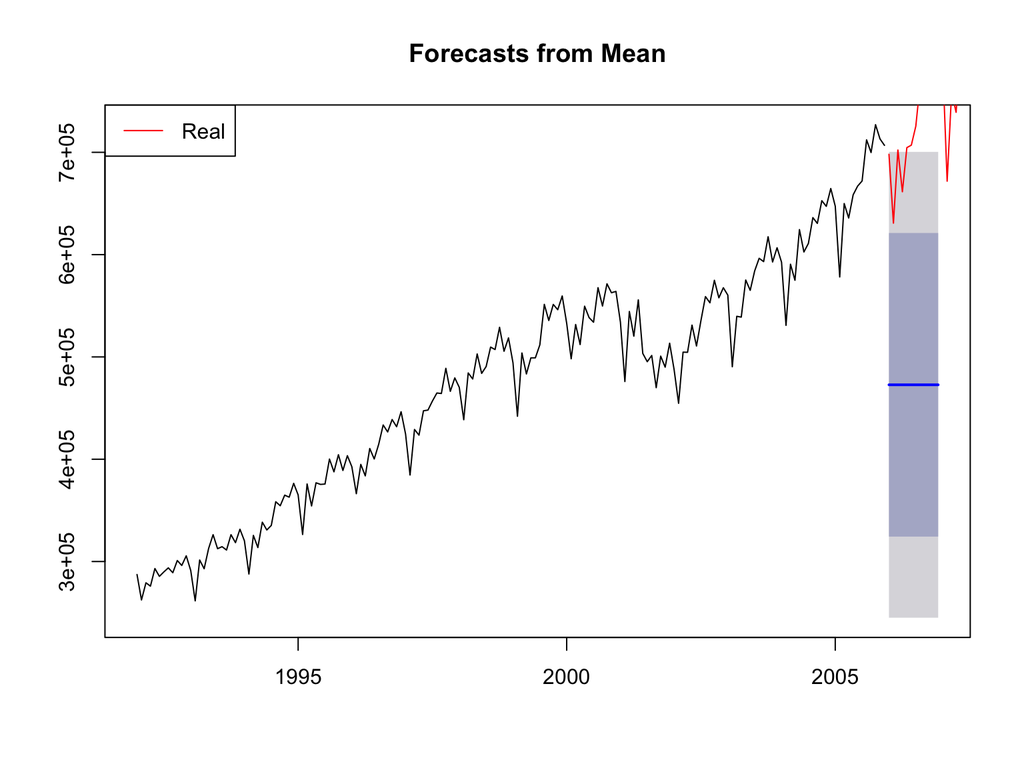

```r
# Média
f_mean <- meanf(tsMensalTrain, h=mesesAPrever)
plot(f_mean)
lines(tsMensalTest, col="red")
legend("topleft",legend=c("Real"),col=2,lty=1)
```

```r
# Acurácia
accuracy(f_mean, tsMensalTest)
```

```
##                     ME   RMSE    MAE    MPE  MAPE  MASE  ACF1 Theil's U
## Training set 1.873e-11 114640  96049 -6.754 22.82 2.589 0.955        NA
## Test set     2.517e+05 256222 251735 34.455 34.45 6.787 0.597     5.948
```

#### Näive

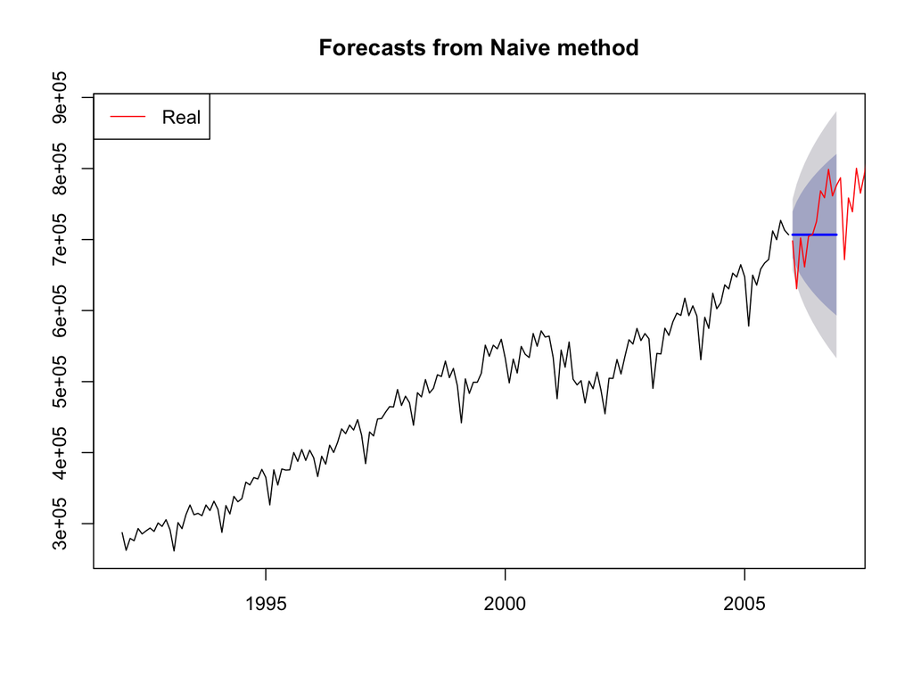

```r
# Näive
f_naive <- naive(tsMensalTrain, h=mesesAPrever)
plot(f_naive)
lines(tsMensalTest, col="red")
legend("topleft",legend=c("Real"),col=2,lty=1)
```

```r
# Acurácia
accuracy(f_naive, tsMensalTest)
```

```
##                 ME  RMSE   MAE    MPE  MAPE   MASE    ACF1 Theil's U
## Training set  2512 25615 20233 0.3872 4.376 0.5455 -0.4858        NA
## Test set     17678 50912 40490 2.0038 5.524 1.0916  0.5970     1.195
```

#### Näive Sazonal

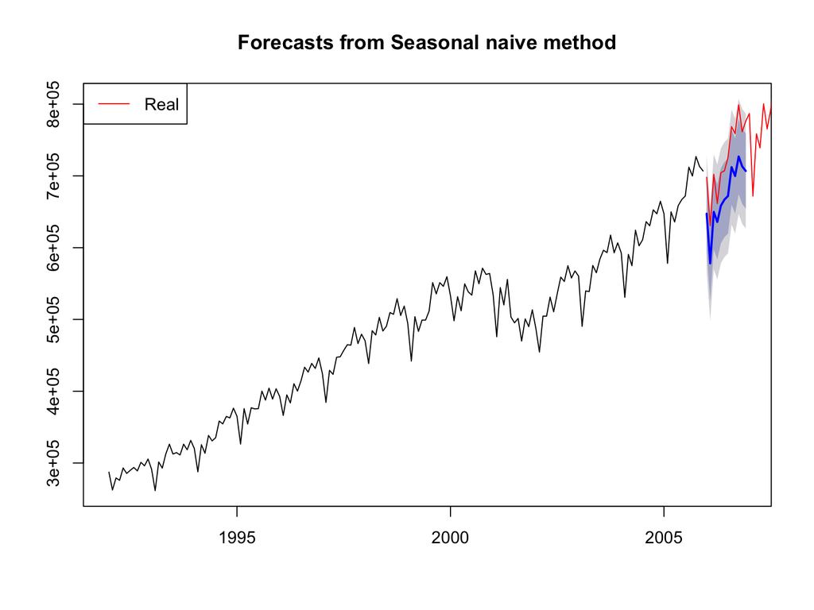

```r
# Näive Sazonal
f_seazonal_naive <- snaive(tsMensalTrain, h=mesesAPrever)
plot(f_seazonal_naive)
lines(tsMensalTest, col="red")
legend("topleft",legend=c("Real"),col=2,lty=1)
```

```r
# Acurácia
accuracy(f_seazonal_naive, tsMensalTest)
```

```
##                 ME  RMSE   MAE   MPE  MAPE  MASE   ACF1 Theil's U
## Training set 29542 40841 37092 6.142 7.673 1.000 0.8846        NA
## Test set     52188 53494 52188 7.163 7.163 1.407 0.1461      1.24
```

#### Drift

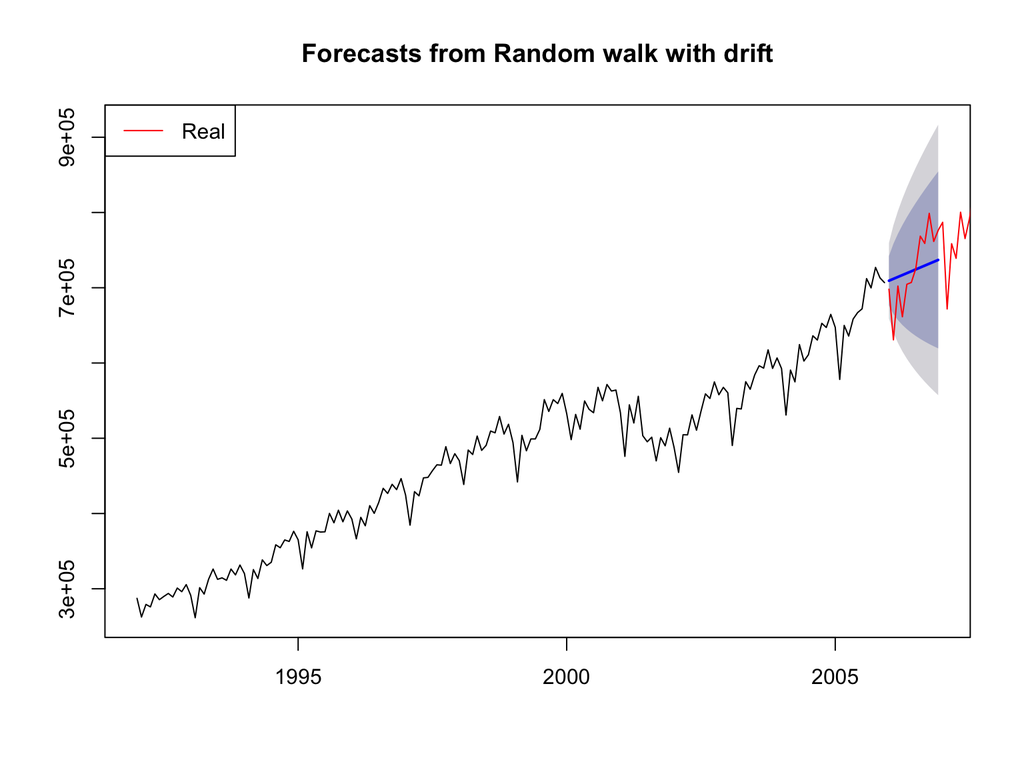

```r
# Drift
f_drift <- rwf(tsMensalTrain, drift = TRUE, h=mesesAPrever)
plot(f_drift)
lines(tsMensalTest, col="red")
legend("topleft",legend=c("Real"),col=2,lty=1)
```

```r
# Acurácia
accuracy(f_drift, tsMensalTest)
```

```
##                      ME  RMSE   MAE     MPE  MAPE   MASE    ACF1 Theil's U
## Training set -7.145e-12 25491 20317 -0.1782 4.408 0.5477 -0.4858        NA
## Test set      1.351e+03 40529 32919 -0.1909 4.601 0.8875  0.4936    0.9733
```

# Modelo médias-móveis

Dado no instante $t$ de uma série temporal é dado pelo valor esperado da variável aleatória acrescida do ruído branco no instante $t$ e a soma ponderada do ruído branco em instantes passados.

O número de instantes passados considerados é dado pela ordem do modelo.

### Médias móveis de ordem 3:

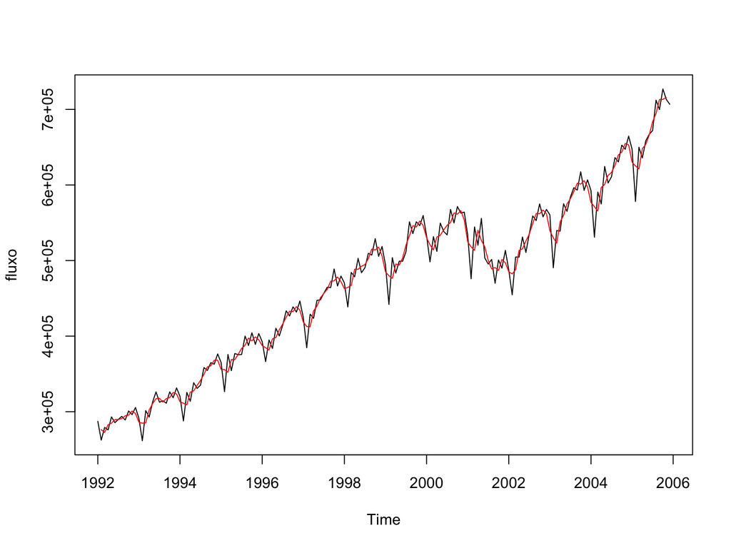

```r
plot(tsMensalTrain)
lines(ma(tsMensalTrain, order=3), col="red")
```

# Modelo auto regressivo

Dado no instante $t$ de uma série temporal é expresso como a média ponderada dos dados em instantes passados acrescida de ruído branco.

O número de instantes passados considerados é dado pela ordem do modelo.

#### Exemplo:

```r
ar_model <- ar(tsMensalTrain)
```

Ordem escolhida automaticamente:

```r
ar_model$order
```

```
## [1] 13
```

Predição:

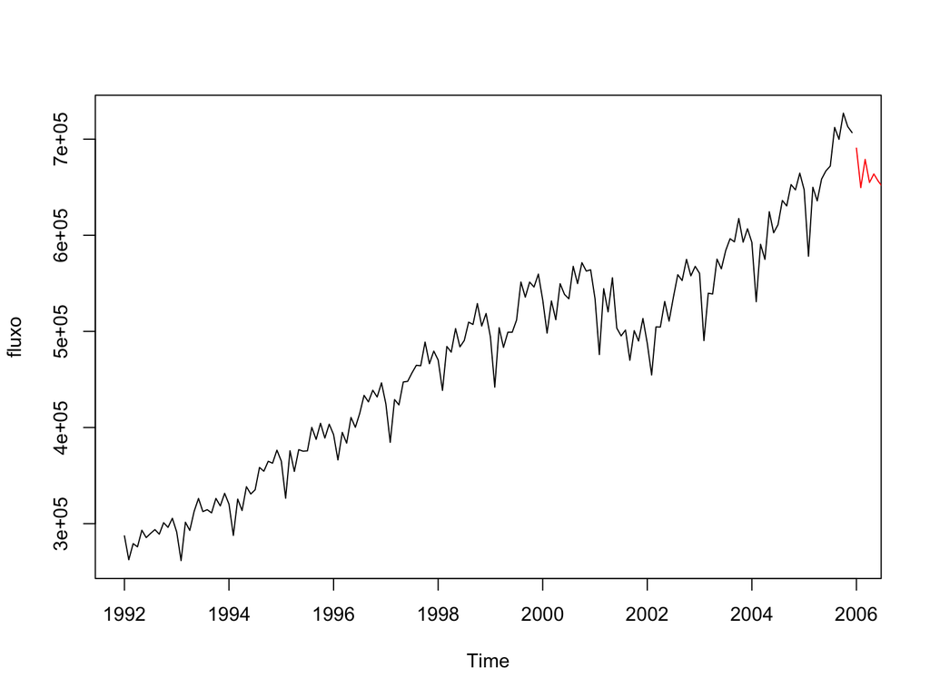

```r
ar_fit <- predict(ar_model, n.ahead = 12)
plot(tsMensalTrain)
lines(ar_fit$pred, col="red")
```

Acurácia:

```r
accuracy(ar_fit$pred, tsMensalTest)
```

```
##             ME  RMSE   MAE   MPE  MAPE   ACF1 Theil's U
## Test set 65950 84307 69075 8.672 9.168 0.7698     1.952
```

# ARIMA

- ARMA: autoregressive moving-average - combinação de ambos
- ARIMA: ARMA com um passo de diferenciação

Modelo:

```r
arima_model <- auto.arima(tsMensalTrain)
```

Predição:

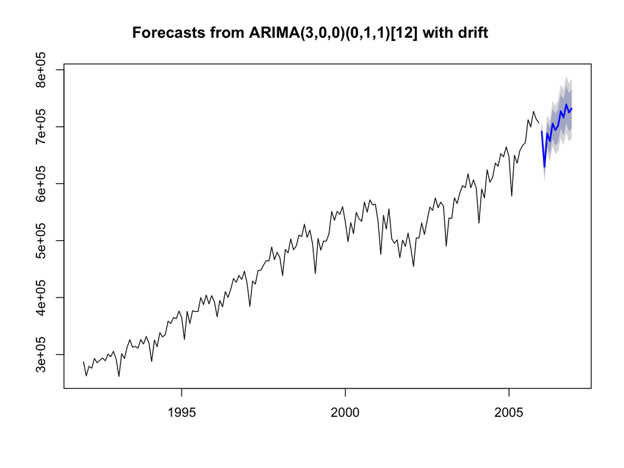

```r
fcast_arima <- forecast(arima_model, h=mesesAPrever)
plot(fcast_arima)
```

Acurácia:

```r
accuracy(fcast_arima, tsMensalTest)
```

```
##                 ME  RMSE   MAE     MPE  MAPE   MASE      ACF1 Theil's U
## Training set   145 10236  7610 -0.0156 1.595 0.2052 -0.005073        NA
## Test set     22409 31001 24765  2.9237 3.278 0.6677  0.697780    0.7174
```

# Exponential Smoothing

Ver (R. J. Hyndman and Athanasopoulos 2013). O mesmo autor possui um livro somente sobre o assunto em (R. Hyndman et al. 2008).

Modelo:

```r
etsMensal <- ets(tsMensalTrain, model="MMM")
# Multiplicative Error
# Multiplicative trend
# Multiplicative Season
```

Prospecção:

```r
fcastMensal <- forecast(etsMensal)
```

Comparar predição com valores reais do conjunto de teste:

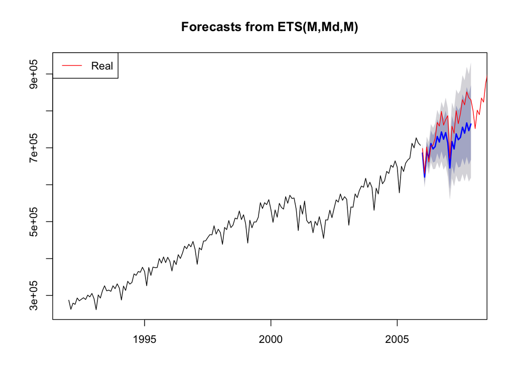

```r
plot(fcastMensal);
lines(tsMensalTest, col="red")
legend("topleft",legend=c("Real"),col=2,lty=1)
```

Acurácia:

```r
accuracy(fcastMensal, tsMensalTest)
```

```
##                 ME  RMSE   MAE    MPE  MAPE   MASE      ACF1 Theil's U
## Training set   910  8952  6764 0.1729 1.438 0.1824 -0.005476        NA
## Test set     41853 50268 43278 5.2980 5.508 1.1668  0.757328     1.021
```

# Exponential Smoothing Automático

```r
etsMensal_auto <- ets(tsMensalTrain)
```

Prospecção:

```r
fcastMensal_auto <- forecast(etsMensal_auto)
```

Comparar predição com valores reais do conjunto de teste:

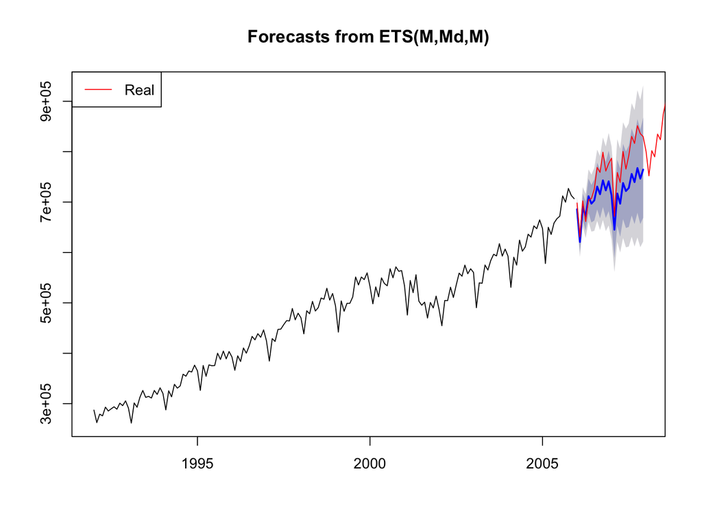

```r
plot(fcastMensal_auto);
lines(tsMensalTest, col="red")
legend("topleft",legend=c("Real"),col=2,lty=1)
```

Acurácia:

```r
accuracy(fcastMensal_auto, tsMensalTest)
```

```
##                 ME  RMSE   MAE    MPE  MAPE   MASE      ACF1 Theil's U
## Training set   910  8952  6764 0.1729 1.438 0.1824 -0.005476        NA
## Test set     41853 50268 43278 5.2980 5.508 1.1668  0.757328     1.021
```

# Referências

Hyndman, Rob J. 2014. “Forecasting Time Series Using R.” http://robjhyndman.com/talks/MelbourneRUG.pdf.

Hyndman, Rob J, and George Athanasopoulos. 2013. *Forecasting: principles and Practice*. OTexts.

Hyndman, Rob, Anne B. Koehler, J. Keith Ord, and Ralph D. Snyder. 2008. *Forecasting with Exponential Smoothing: The State Space Approach (Springer Series in Statistics)*. 2008th ed. Springer. http://amazon.com/o/ASIN/3540719164/.

Leek, Jeffrey. 2014. “Practical Machine Learning - Lecture 27 - Forecasting.” Johns Hopkins Bloomberg School of Public Health. https://d396qusza40orc.cloudfront.net/predmachlearn/027forecasting.pdf.